# Inference for Linear Regression

Elementary Statistics

MTH-161D | Spring 2025 | University of Portland

April 14, 2025

# Objectives

- **Introduce inference for linear regression**
- **Develop an understanding of the sampling distribution of the slope and intercept**
- **Know how to compute the confidence intervals of the slope and intercept**
- **Activity: Determine Confidence Intervals of a Linear Model**

# Previously… (1/2)

**Linear Regression**

$$y = \beta_0 + \beta_1 x +
\epsilon$$

- $y$ is the outcome, $x$ is the predictor, $\beta_0$ is the intercept, and $\beta_1$ is the slope. The notation $\epsilon$ is the model’s error (residuals).
- We estimate the slope $b_1$ and intercept $b_0$ of the least squares regression line by minimizing the sum of squared residuals.
- The slope is given by $b_1 = \frac{s_y}{s_x} r$ , and the intercept is $b_0 = \bar{y} - b_1 \bar{x}$ , where $r$ is the correlation coefficient, $s_x$ and $s_y$ are the standard deviations of $x$ and $y$, and $\bar{x}$, $\bar{y}$ are their respective means.

# Previously… (2/2)

**Confidence Interval**

$$\text{point estimate} \pm z^*
SE$$

where $SE$ is the standard error and $z^*$ is the critical z-value for a given confidence level assuming a standard normal distribution. Use $t_{df}^*$ for assuming a t-distribution given degrees of freedom $df$.

# Case Study I

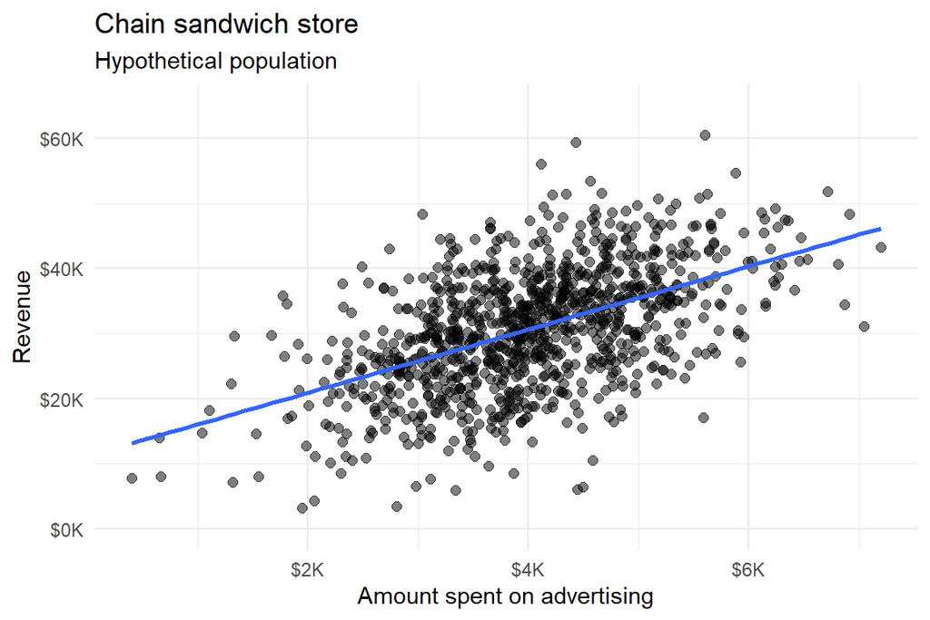

Revenue as a linear model of advertising dollars for a population of sandwich stores, in thousands of dollars.

There are 1000 stores in our sample. Suppose that we know the population slope $\beta_1 = 4.7$ and intercept $\beta_0 = 12$.

# Case Study I: The Linear Model

The population model is:
$$y_{revenue} =
\beta_0 + \beta_1 x_{advertising} + e$$
where $y$ is the response, $x$ is the predictor, $\beta_0$ is the intercept, $\beta_1$ is the slope, and $e$ is the error term.

The least squares regression model uses the data to find a best linear fit:
$$\hat{y}_{revenue} = b_0 + b_1
x_{advertising}.$$
where $b_0 = 11.23$, $b_1 = 4.85$. There will be our point estimates.

# Case Study I: Resdiual Analysis (1/2)

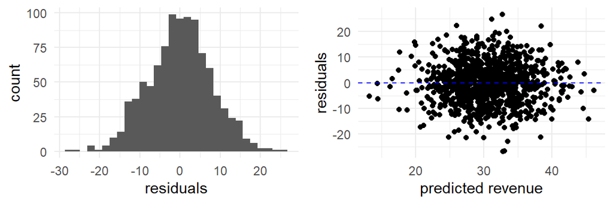

- The residuals appear approximately normal, supporting the normality assumption.
- The residual plot shows roughly constant variance, suggesting homoskedasticity.
- Slight clustering near the center may require further investigation but otherwise the residuals are independent of the model (no pattern).

# Case Study I: Resdiual Analysis (2/2)

A **Q-Q plot (quantile-quantile plot)** is a graphical tool used to assess whether a dataset follows a particular theoretical distribution—most commonly, the normal distribution.

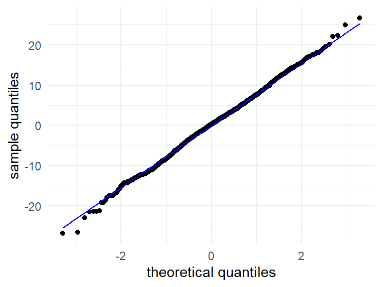

- In regression, we often use a Q-Q plot of residuals to check if they are normally distributed –one of the important assumptions for valid inference for linear regression.
- Quick interpretation:
  - Straight line means normality is a reasonable assumption.
  - Curved or S-shaped means deviations from normality.
  - Outliers far from the line means possible extreme values.

# Case Study I: Variability of the Statistic (1/4)

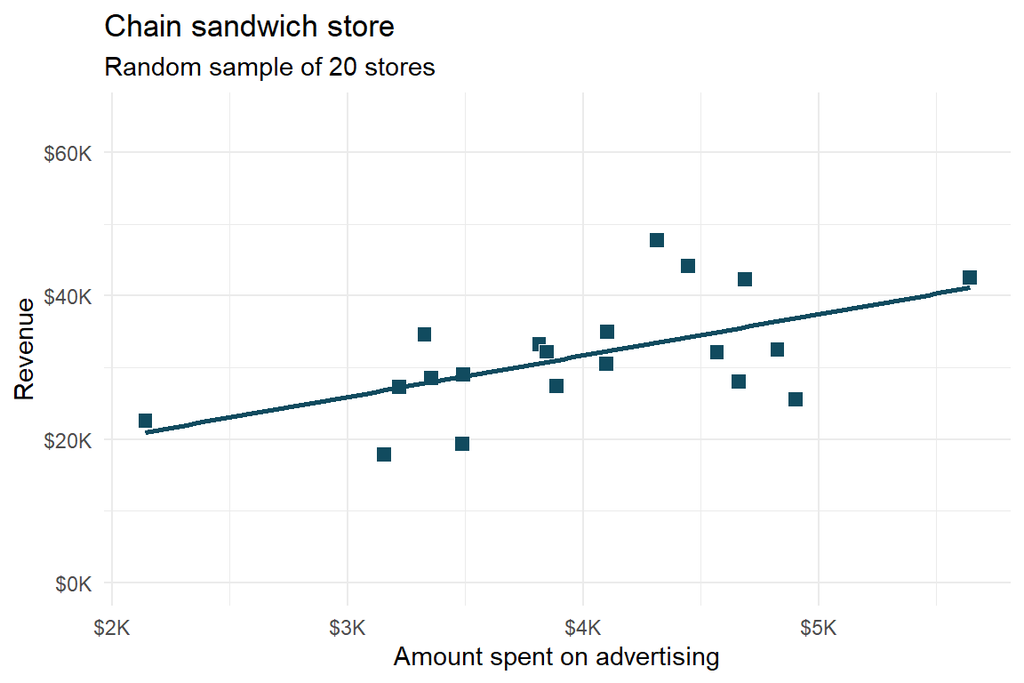

A random sample of 20 stores from the entire population. A linear trend between advertising and revenue continues to be observed.

# Case Study I: Variability of the Statistic (2/4)

A second sample of size 20 also shows a positive trend!

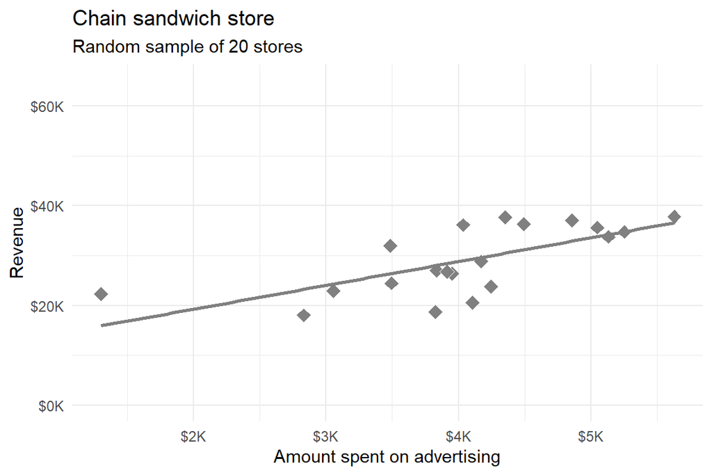

A different random sample of 20 stores from the entire population. Again, a linear trend between advertising and revenue is observed.

# Case Study I: Variability of the Statistic (3/4)

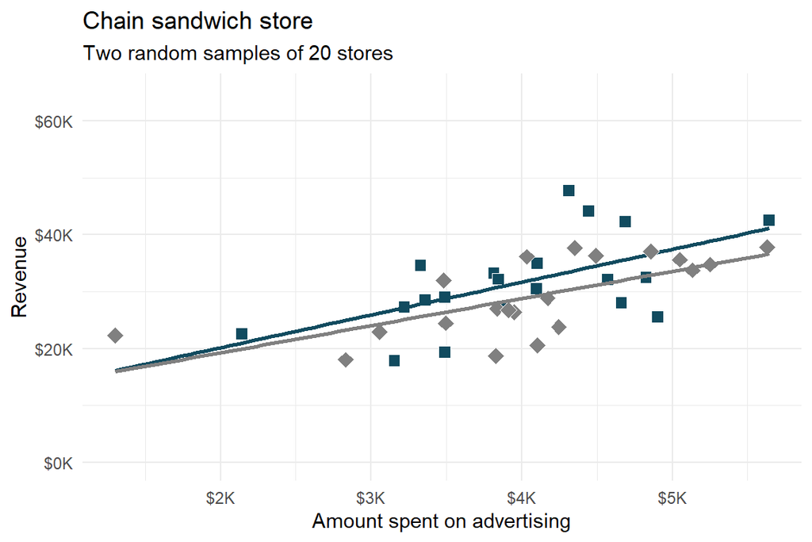

The linear models from the two different random samples are quite similar, but they are not the same line.

# Case Study I: Variability of the Statistic (4/4)

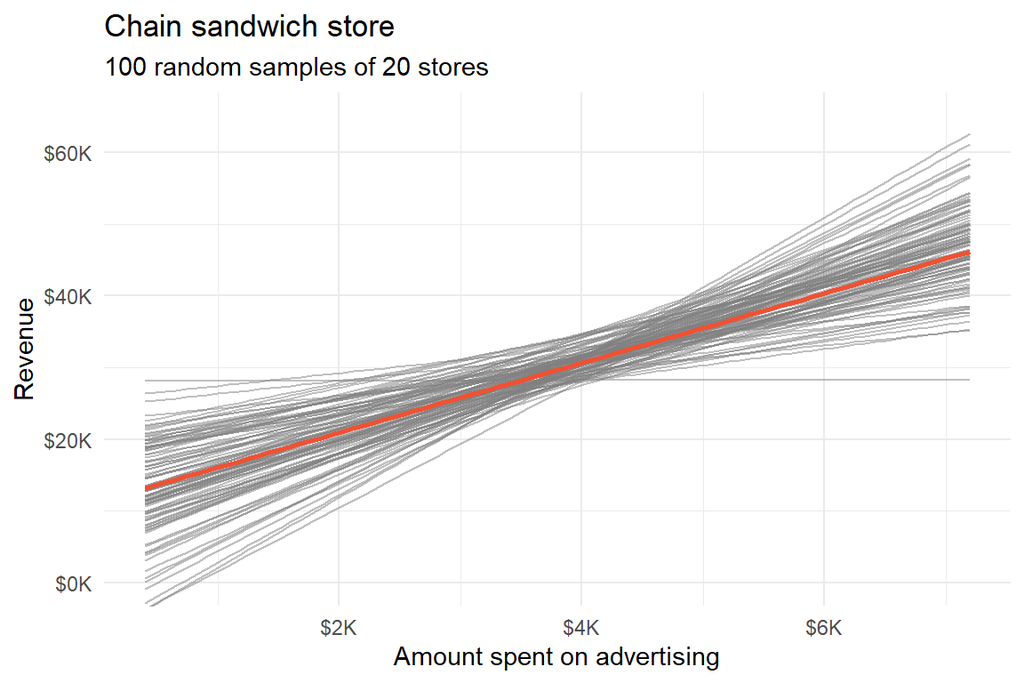

If repeated samples of size 20 are taken from the entire population, each linear model will be slightly different. The red line provides the linear fit to the entire population.

# Case Study I: Sampling Distribution of the Slope Estimate

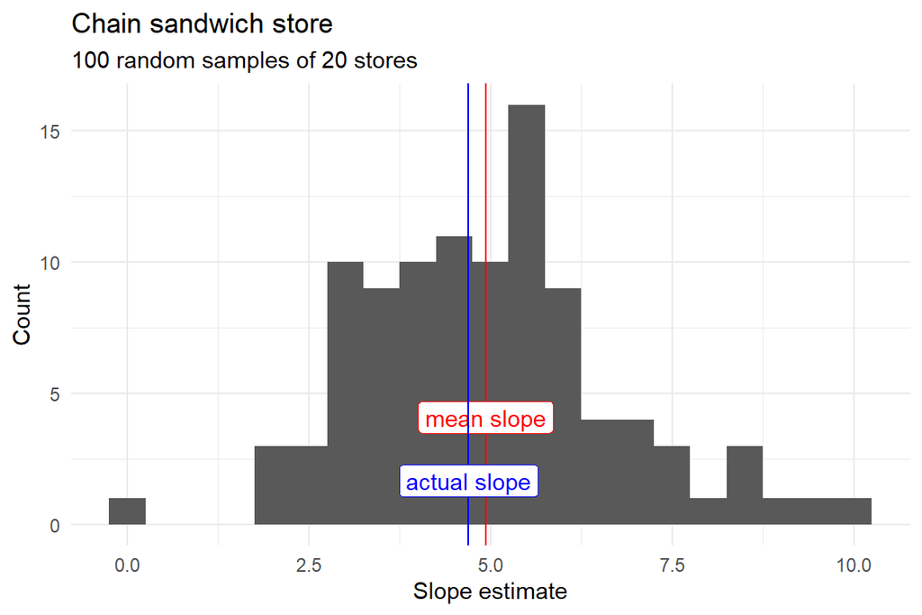

Variability of slope estimates taken from many different samples of stores, each of size 20.

# Case Study I: Confidence Interval

The 95% Confidence interval for the slope and intercept using the bootstrapped samples. Here, we are using the percentiles of the bootstrapped samples to estimate the confidence interval.

| term | estimate | lower bound | upper bound |
| --- | --- | --- | --- |
| $b_0$ | 11.3215 | 9.5334 | 12.9665 |
| $b_1$ | 4.8254 | 4.4023 | 5.2861 |

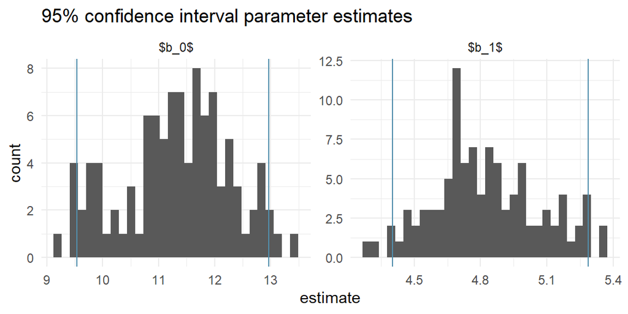

# Case Study I: Best Fit Line and Confidence Interval

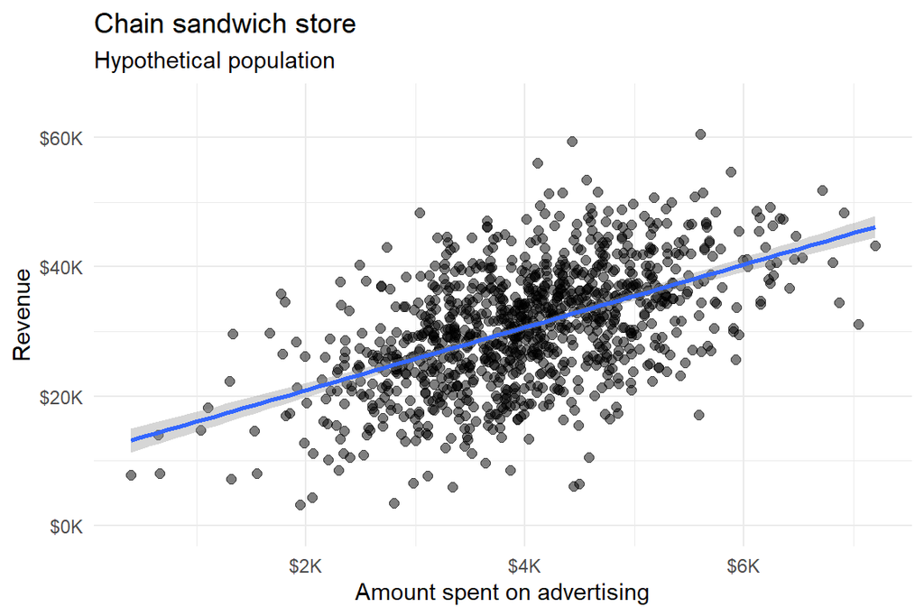

# Using the $t$-distribution (1/2)

An alternative to the bootstrapping method is using the $t$-distribution to determine the confidence interval at a given confidence level.

The confidence intervals for the slope $b_1$ and intercept $b_1$ estimates is given by

$$\begin{aligned}
\text{slope } \longrightarrow b_1 \pm t_{df}^* \text{SE}_{b_1} \\
\text{intercept } \longrightarrow b_0 \pm t_{df}^* \text{SE}_{b_0}
\end{aligned}$$

where $\text{SE}_{b_1}$ and $\text{SE}_{b_0}$ are the standard errors for the slope and intercept sampling distributions respectively. The critical $t_{df}^*$ is computed using the $t$-distribution given a confidence level and degrees of freedom, $df = n - 1$, where $n$ is the sample size.

# Using the $t$-distribution (2/2)

Computing the standard errors $\text{SE}_{b_1}$ and $\text{SE}_{b_0}$ are *fairly complicated* and it is usually computed via functions or bootstrapping simulations using software –such as R.

- $s$ is the standard error of the regression, $s = s_{\epsilon} \sqrt{\frac{n-1}{n-2}}$, where $s_{\epsilon}$ is the standard deviation of the residual errors
- $\bar{x}$ is the mean of $x$, the explanatory variable
- $s_x$ is the standard deviation of $x$
- $n$ is the sample size

# Case Study I: Confidence Intervals using the $t$-Distribution (1/2)

The summary statistics of our explanatory and response variables are given below, which includes the correlation coefficient.

| statistics | estimates |
| --- | --- |
| $\bar{x}$ | 4.0137 |
| $\bar{y}$ | 30.7142 |
| $s_x$ | 0.9909 |
| $s_y$ | 9.2371 |
| $r$ | 0.5207 |

| term | estimate | SE |
| --- | --- | --- |
| $b_0$ | 11.2334 | 1.0415 |
| $b_1$ | 4.8536 | 0.2519 |

# Case Study I: Confidence Intervals using the $t$-Distribution (2/2)

The goal is to determine the 95% confidence interval of the slope and intercept estimates using the $t$-distribution approach.

- The degrees of freedom is $df = n - 1 = 1000 - 1 = 999$
- For a $0.95$ confidence level $t_{df}^* = t_{999}^* \approx 1.9623$
- 95% confidence interval for the slope estimate:

$$\begin{aligned}
b_1 & \pm t_{df}^* \times \text{SE}_{b_1} \\
4.8536 & \pm 1.9623 \times 0.2519
\end{aligned}$$
$$(4.3593,5.3479)$$

- 95% confidence interval for the intercept estimate:

$$\begin{aligned}
b_0 & \pm t_{df}^* \times \text{SE}_{b_0} \\
11.2334 & \pm 1.9623 \times 1.0415
\end{aligned}$$
$$(9.1897,13.2771)$$

The intervals computed using the $t$-distribution is assuming the CLT conditions and the results here are are approximately equal to the intervals computed using the bootstrapping method.

# Activity: Determine Confidence Intervals of a Linear Model

# References

Diez, D. M., Barr, C. D., & Çetinkaya-Rundel, M. (2012). *OpenIntro statistics* (4th ed.). OpenIntro. https://www.openintro.org/book/os/